# A Summary of The Data and Explanations

POLAT ALEMD~R

## Understanding Turkey Council of Higher Education Facts

### Preparation and Introduction of Planning Data

There are three different data sources in this analysis. We have improved raw data and omitted unnecessary fields. Below you can see the format of three different data sources which includes, students information with university facts, exchange students facts and university entrance exam figures.

### 1st Data Source - University Statistics

5 Year of Academy Year Data: This raw data includes 909 rows and 15 variables related to Turkey Council of High Education between 2014-2015 and 2018-2019 statistics related to universites and their students. There are currently 207 universities available in Turkey in 2019 year. Our database includes 242 universities most of them are closed after 2015-2016 education year.

```r
tmp=tempfile(fileext=".xlsx")

download.file("https://github.com/pjournal/mef03g-polatalemd-r/blob/master/university_statistics_2019-2014.xlsx?raw=true",destfile=tmp,mode='wb')
raw_data=readxl::read_excel(tmp)
file.remove(tmp)
```

```r
head(raw_data, 10)
```

```
## # A tibble: 10 x 15
##    name_of_univers~ year_of_educati~ type_of_univers~ city  onlisans_male
##    <chr>            <chr>            <chr>            <chr>         <dbl>
##  1 ABANT IZZET BAY~ 2018-2017        DEVLET           BOLU           6230
##  2 ABANT IZZET BAY~ 2017-2016        DEVLET           BOLU           6222
##  3 ABANT IZZET BAY~ 2016-2015        DEVLET           BOLU           5649
##  4 ABANT IZZET BAY~ 2015-2014        DEVLET           BOLU           4269
##  5 ABDULLAH GUL UN~ 2019-2018        DEVLET           KAYS~             0
##  6 ABDULLAH GUL UN~ 2018-2017        DEVLET           KAYS~             0
##  7 ABDULLAH GUL UN~ 2017-2016        DEVLET           KAYS~             0
##  8 ABDULLAH GUL UN~ 2016-2015        DEVLET           KAYS~             0
##  9 ABDULLAH GUL UN~ 2015-2014        DEVLET           KAYS~             0
## 10 ACIBADEM MEHMET~ 2019-2018        VAKIF            ISTA~           514
## # ... with 10 more variables: onlisans_female <dbl>, lisans_male <dbl>,
## #   lisans_female <dbl>, master_male <dbl>, master_female <dbl>,
## #   doctorate_male <dbl>, doctorate_female <dbl>, total_male <dbl>,
## #   total_female <dbl>, total_total <dbl>
```

### 2nd Data Source - Exchange Program Facts

```r
tmp=tempfile(fileext=".xlsx")

download.file("https://github.com/pjournal/mef03g-polatalemd-r/blob/master/rawdata_exchange_students.xlsx?raw=true",destfile=tmp,mode='wb')
rawdata_exchange_students=readxl::read_excel(tmp)
file.remove(tmp)
```

```r
head(rawdata_exchange_students, 10)
```

```
## # A tibble: 10 x 25
##    name_of_univers~ type_of_univers~ city  year_of_educati~
##    <chr>            <chr>            <chr> <chr>
##  1 ACIBADEM MEHMET~ VAKIF            ISTA~ 2018_2019
##  2 ADANA ALPARSLAN~ DEVLET           ADANA 2018_2019
##  3 ADANA BILIM VE ~ DEVLET           ADANA 2018_2019
##  4 ADIYAMAN UNIVER~ DEVLET           ADIY~ 2018_2019
##  5 AFYON KOCATEPE ~ DEVLET           AFYO~ 2018_2019
##  6 AFYONKARAHISAR ~ DEVLET           AFYO~ 2018_2019
##  7 AGRI IBRAHIM CE~ DEVLET           AGRI  2018_2019
##  8 AKDENIZ UNIVERS~ DEVLET           ANTA~ 2018_2019
##  9 AKSARAY UNIVERS~ DEVLET           AKSA~ 2018_2019
## 10 ALANYA ALAADDIN~ DEVLET           ANTA~ 2018_2019
## # ... with 21 more variables: farabigiden_male <dbl>,
## #   farabigiden_female <dbl>, farabigiden_toplam <dbl>,
## #   farabigelen_male <dbl>, farabigelen_female <dbl>,
## #   farabigelen_total <dbl>, mevlanagiden_male <dbl>,
## #   mevlanagiden_female <dbl>, mevlanagiden_total <dbl>,
## #   mevlanagelen_male <dbl>, mevlanagelen_female <dbl>,
## #   mevlanagelen_total <dbl>, erasmusgiden_male <dbl>,
## #   erasmusgiden_female <dbl>, erasmusgiden_total <dbl>,
## #   erasmusgelen_male <dbl>, erasmusgelen_female <dbl>,
## #   erasmusgelen_total <dbl>, male_total <dbl>, female_total <dbl>,
## #   total_total <dbl>
```

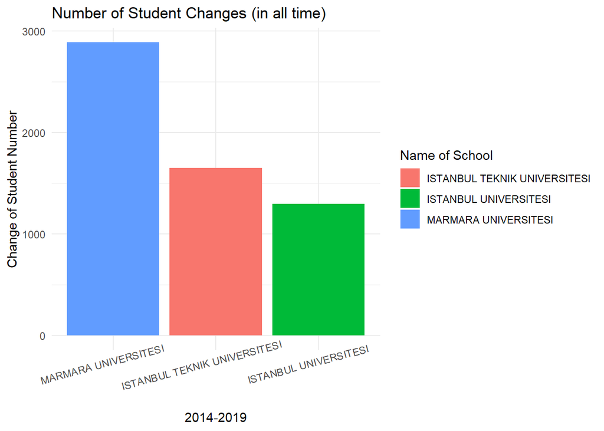

```r
library(dplyr)
library(ggplot2)
most_student_gain <- rawdata_exchange_students %>% transmute(name_of_university, year_of_education,
                                        total_giden = farabigiden_toplam + mevlanagiden_total + erasmusgiden_total,
                                        total_gelen = farabigelen_total + mevlanagelen_total + erasmusgelen_total,
                                        change_of_studentnum = total_gelen - total_giden) %>%
  select(name_of_university, total_gelen, total_giden, change_of_studentnum)%>%
  group_by(name_of_university) %>% transmute(total_gelen = sum(total_gelen), total_giden=sum(total_giden),
                                          change_of_studentnum=sum(change_of_studentnum)) %>% distinct() %>%
  arrange(desc(change_of_studentnum)) %>% filter(change_of_studentnum>1000)


most_student_gain %>% ggplot(data=., aes(x=name_of_university, y=change_of_studentnum, fill=name_of_university)) +
  geom_bar(stat="identity", position=position_dodge())+ aes(x = reorder(name_of_university, -change_of_studentnum), y = change_of_studentnum) +
  labs(x = "2014-2019",y= "Change of Student Number", title = "Number of Student Changes (in all time)", fill= "Name of School") +
  theme_minimal() + theme(axis.text.x = element_text(angle = 15, hjust = 0.6))
```

### 3rd Data Source - Student Admission Examination Analyses

There are 135 observations and 18 variables.

This data enables us to oversee facts related to student admission exam trend in Turkey over 5 year data. with some fractions below without limitation: student with highest education before admission, student whether studied in a university before, students’ with background of types of schools

```r
tmp <- tempfile(fileext = ".xlsx")

download.file("https://github.com/pjournal/mef03g-polatalemd-r/blob/master/2015-2019_YKS_BASVURAN_YERLESEN_.xlsx?raw=true",destfile = tmp,mode = 'wb')

YKS_BASVURAN_YERLESEN <- readxl::read_excel(tmp ,col_names = TRUE)

file.remove(tmp)

colnames(YKS_BASVURAN_YERLESEN) <- c("okul_turu","yil","son_sinif_duzeyinde_basvuran",
                         "son_sinif_duzeyinde_yerlesen_lisans","son_sinif_duzeyinde_yerlesen_onlisans","son_sinif_duzeyinde_yerlesen_ao",
                         "mezun_daha_once_yerlesmemis_basvuran","mezun_daha_once_yerlesmemis_yerlesen_lisans","mezun_daha_once_yerlesmemis_yerlesen_onlisans","mezun_daha_once_yerlesmemis_yerlesen_ao",
                         "bir_yuksek_ogretim_kurumu_bitirmis_basvuran","bir_yuksek_ogretim_kurumu_bitirmis_yerlesen_lisans","bir_yuksek_ogretim_kurumu_bitirmis_yerlesen_onlisans","bir_yuksek_ogretim_kurumu_bitirmis_yerlesen_ao",
                         "daha_once_yerlesmis_basvuran","daha_once_yerlesmis_yerlesen_lisans","daha_once_yerlesmis_yerlesen_onlisans","daha_once_yerlesmis_yerlesen_ao")
```

```r
head(YKS_BASVURAN_YERLESEN, 10)
```

```
## # A tibble: 10 x 18
##    okul_turu   yil son_sinif_duzey~ son_sinif_duzey~ son_sinif_duzey~
##    <chr>     <dbl>            <dbl>            <dbl>            <dbl>
##  1 LISE (RE~  2015           245655            50218            34831
##  2 OZEL LISE  2015             1607              566              215
##  3 ANADOLU ~  2015           163202            92723             9206
##  4 YABANCI ~  2015            29748            19185             1345
##  5 FEN LISE~  2015             9915             6270               35
##  6 OZEL FEN~  2015             3563             2805               14
##  7 ASKERI L~  2015               22                5                0
##  8 AKSAM LI~  2015                0                0                0
##  9 OZEL AKS~  2015              414               33               78
## 10 LISE , O~  2015                0                0                0
## # ... with 13 more variables: son_sinif_duzeyinde_yerlesen_ao <dbl>,
## #   mezun_daha_once_yerlesmemis_basvuran <dbl>,
## #   mezun_daha_once_yerlesmemis_yerlesen_lisans <dbl>,
## #   mezun_daha_once_yerlesmemis_yerlesen_onlisans <dbl>,
## #   mezun_daha_once_yerlesmemis_yerlesen_ao <dbl>,
## #   bir_yuksek_ogretim_kurumu_bitirmis_basvuran <dbl>,
## #   bir_yuksek_ogretim_kurumu_bitirmis_yerlesen_lisans <dbl>,
## #   bir_yuksek_ogretim_kurumu_bitirmis_yerlesen_onlisans <dbl>,
## #   bir_yuksek_ogretim_kurumu_bitirmis_yerlesen_ao <dbl>,
## #   daha_once_yerlesmis_basvuran <dbl>,
## #   daha_once_yerlesmis_yerlesen_lisans <dbl>,
## #   daha_once_yerlesmis_yerlesen_onlisans <dbl>,
## #   daha_once_yerlesmis_yerlesen_ao <dbl>
```

```r
YKS_BASVURAN_YERLESEN %>% group_by(yil) %>%
  summarise(total_basvuran_son_sinif = sum(son_sinif_duzeyinde_basvuran),total_yerlesen_son_sinif = sum(son_sinif_duzeyinde_yerlesen_lisans)+sum(son_sinif_duzeyinde_yerlesen_onlisans)+sum(son_sinif_duzeyinde_yerlesen_ao))
```

[output not shown]